# Part2_Project

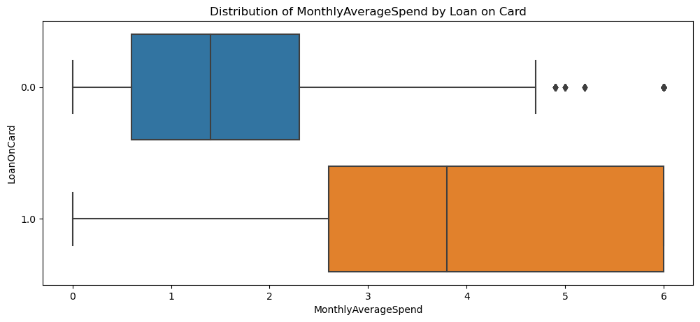

```python
plt.figure(figsize=(12,5), dpi = 100)
sns.boxplot(x=df["MonthlyAverageSpend"], y = df["LoanOnCard"])
plt.title("Distribution of MonthlyAverageSpend by Loan on Card")
plt.show();
```

```python
# highest spend and monthly spend is higher among customers with loan on card;
# there are outliers in customer without loan on card, which is expected behavior
```

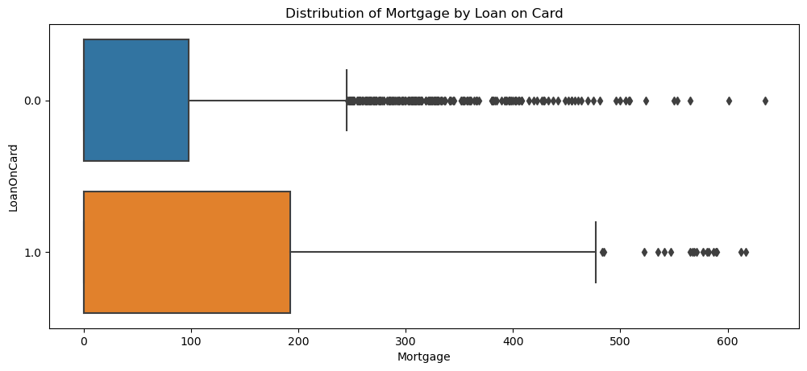

```python
plt.figure(figsize=(12,5), dpi = 100)
sns.boxplot(x=df["Mortgage"], y = df["LoanOnCard"])
plt.title("Distribution of Mortgage by Loan on Card")
plt.show();
```

```python
# customers with loan on card have larger mortgage units
```

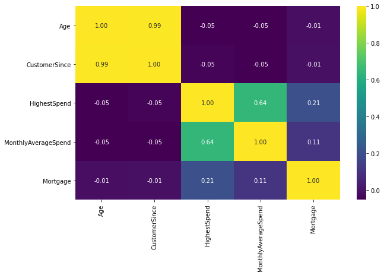

```python
plt.figure(figsize=(10,6))
sns.heatmap(df.corr(),cmap='viridis',annot=True, fmt= '.2f');
```

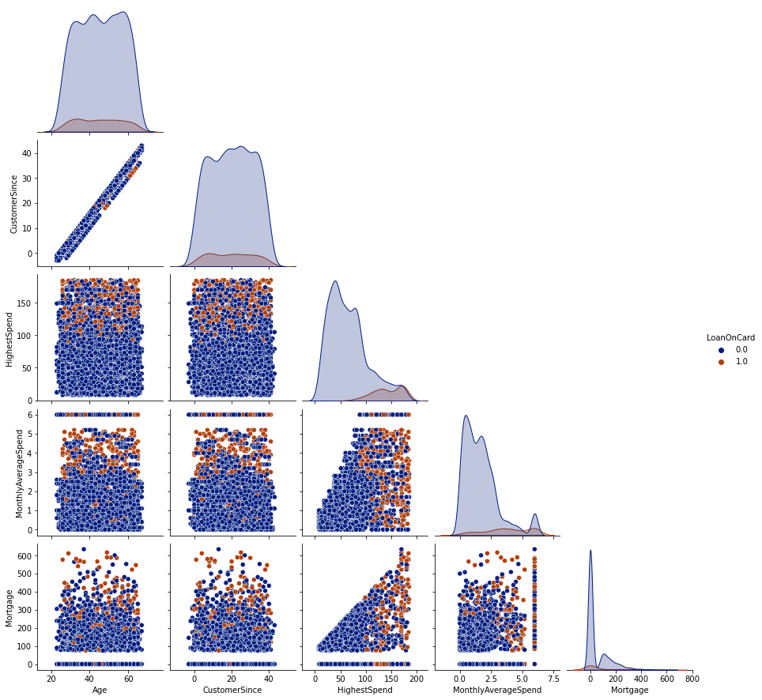

```python
sns.pairplot(df, hue="LoanOnCard", palette = "dark", corner=True);
```

```python
# strong positive relation between customer since and age, highestspend & monthly spend
```

1. Data pre-processing:  
   • Segregate predictors vs target attributes  
   • Check for target balancing and fix it if found imbalanced.  
   • Perform train-test split.

Creating a model using stratify and class weight parameter

```python
# separate the target and features and perform train-test split
X = df.drop(['LoanOnCard'],axis=1)
y = df['LoanOnCard']
```

```python
df['LoanOnCard'].value_counts(normalize=True) * 100
```

```
0.0    90.361446
1.0     9.638554
Name: LoanOnCard, dtype: float64
```

```python
# train test split; as the target is imbalanced we will use stratify parameter to see if we end up with a good model
from sklearn.model_selection import train_test_split
from sklearn.preprocessing import StandardScaler
```

```python
# as the target class is imbalanced, we will try stratify and class weight parameter to balance
X_train, X_test, y_train, y_test = train_test_split(X, y, test_size=0.10, random_state=42,stratify=y)
scaler = StandardScaler()
scaled_X_train = scaler.fit_transform(X_train)
scaled_X_test = scaler.transform(X_test)
```

```python
from sklearn.linear_model import LogisticRegressionCV
log_model = LogisticRegressionCV(class_weight="balanced")
log_model.fit(scaled_X_train,y_train)
```

```
LogisticRegressionCV(class_weight='balanced')
```

```python
print(list(log_model.Cs_))
```

```
[0.0001, 0.000774263682681127, 0.005994842503189409, 0.046415888336127774, 0.3593813663804626, 2.782559402207126, 21.54434690031882, 166.81005372000558, 1291.5496650148827, 10000.0]
```

```python
print(log_model.C_)
```

```
[21.5443469]
```

```python
pd.DataFrame.from_dict(log_model.get_params(), orient ='index').T
```

|  | Cs | class_weight | cv | dual | fit_intercept | intercept_scaling | l1_ratios | max_iter | multi_class | n_jobs | penalty | random_state | refit | scoring | solver | tol | verbose |
| --- | --- | --- | --- | --- | --- | --- | --- | --- | --- | --- | --- | --- | --- | --- | --- | --- | --- |
| 0 | 10 | balanced | None | False | True | 1 | None | 100 | auto | None | l2 | None | True | None | lbfgs | 0.0001 | 0 |

```python
log_model.coef_
```

```
array([[-0.79973468,  0.8439484 ,  2.4490489 ,  0.65657392,  0.52088246,
         1.16953376,  0.02394791, -0.43949637,  0.92907262, -0.31869818,
        -0.40688297]])
```

```python
from sklearn.metrics import confusion_matrix,classification_report,plot_confusion_matrix
y_pred = log_model.predict(scaled_X_test)
confusion_matrix(y_test,y_pred)
```

```
array([[401,  49],
       [  5,  43]])
```

```python
print(classification_report(y_test,y_pred))
```

```
              precision    recall  f1-score   support

         0.0       0.99      0.89      0.94       450
         1.0       0.47      0.90      0.61        48

    accuracy                           0.89       498
   macro avg       0.73      0.89      0.78       498
weighted avg       0.94      0.89      0.91       498
```

```python
print(f'Accuracy on Training data: {log_model.score(scaled_X_train, y_train)}' )
print(f'Accuracy on Test data: {log_model.score(scaled_X_test, y_test)}' )
```

```
Accuracy on Training data: 0.8942436412315931
Accuracy on Test data: 0.891566265060241
```

```python
# the above model though has a good recall does not have a good precision score
```

1. Model training, testing and tuning:  
   • Design and train a Logistic regression and Naive Bayes classifiers.  
   • Display the classification accuracies for train and test data.  
   • Display and explain the classification report in detail.  
   • Apply all the possible tuning techniques to train the best model for the given data. Select the final best trained model with your comments for selecting this model.

```python
# we will use SMOTENC to balance the target class and see if we get better predictions
```

```python
# separate the target and features and perform train-test split
X = df.drop(['LoanOnCard'],axis=1)
y = df['LoanOnCard']
```

```python
df.columns
```

```
Index(['Age', 'CustomerSince', 'HighestSpend', 'HiddenScore',
       'MonthlyAverageSpend', 'Level', 'Mortgage', 'Security',
       'FixedDepositAccount', 'InternetBanking', 'CreditCard', 'LoanOnCard'],
      dtype='object')
```

```python
# resample X, y
from imblearn.over_sampling import SMOTENC
smote_nc = SMOTENC(categorical_features=[3, 5, 7, 8,9,10], random_state=42)
X, y = smote_nc.fit_resample(X, y)
```

```python
X_train, X_test, y_train, y_test = train_test_split(X, y, test_size=0.10, random_state=42)
scaler = StandardScaler()
scaled_X_train = scaler.fit_transform(X_train)
scaled_X_test = scaler.transform(X_test)
```

```python
log_model = LogisticRegressionCV()
log_model.fit(scaled_X_train,y_train)
```

```
LogisticRegressionCV()
```

```python
log_model.Cs_
```

```
array([1.00000000e-04, 7.74263683e-04, 5.99484250e-03, 4.64158883e-02,
       3.59381366e-01, 2.78255940e+00, 2.15443469e+01, 1.66810054e+02,
       1.29154967e+03, 1.00000000e+04])
```

```python
log_model.C_
```

```
array([0.04641589])
```

```python
pd.DataFrame.from_dict(log_model.get_params(), orient ='index').T
```

|  | Cs | class_weight | cv | dual | fit_intercept | intercept_scaling | l1_ratios | max_iter | multi_class | n_jobs | penalty | random_state | refit | scoring | solver | tol | verbose |
| --- | --- | --- | --- | --- | --- | --- | --- | --- | --- | --- | --- | --- | --- | --- | --- | --- | --- |
| 0 | 10 | None | None | False | True | 1 | None | 100 | auto | None | l2 | None | True | None | lbfgs | 0.0001 | 0 |

```python
log_model.coef_
```

```
array([[-0.13426725,  0.20334995,  2.66868442,  0.68376065,  0.63806355,
         1.21111301,  0.17248401, -0.45154999,  0.8713065 , -0.00740181,
        -0.52579244]])
```

```python
from sklearn.metrics import confusion_matrix,classification_report,plot_confusion_matrix
y_pred = log_model.predict(scaled_X_test)
confusion_matrix(y_test,y_pred)
```

```
array([[400,  45],
       [ 45, 410]])
```

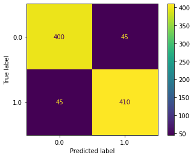

```python
plot_confusion_matrix(log_model,scaled_X_test,y_test);
```

```python
print(classification_report(y_test,y_pred))
```

```
              precision    recall  f1-score   support

         0.0       0.90      0.90      0.90       445
         1.0       0.90      0.90      0.90       455

    accuracy                           0.90       900
   macro avg       0.90      0.90      0.90       900
weighted avg       0.90      0.90      0.90       900
```

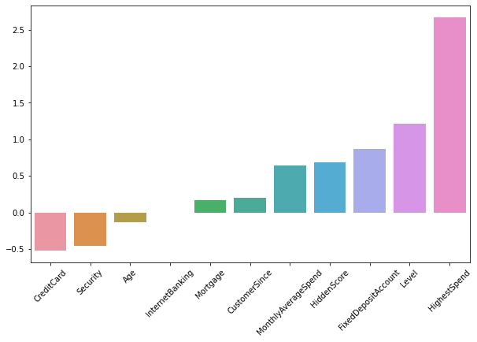

```python
coefs = pd.Series(index=X.columns,data=log_model.coef_[0]).sort_values()
plt.figure(figsize=(10,6))
sns.barplot(x=coefs.index,y=coefs.values)
plt.xticks(rotation=45);
```

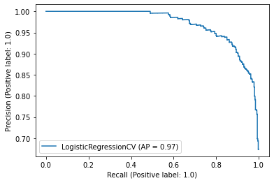

```python
from sklearn.metrics import plot_precision_recall_curve,plot_roc_curve
plot_precision_recall_curve(log_model,scaled_X_test,y_test);
```

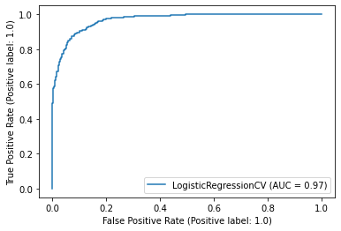

```python
plot_roc_curve(log_model,scaled_X_test,y_test);
```

```python
print(f'Accuracy on Training data: {log_model.score(scaled_X_train, y_train)}' )
print(f'Accuracy on Test data: {log_model.score(scaled_X_test, y_test)}' )
```

```
Accuracy on Training data: 0.912716049382716
Accuracy on Test data: 0.9
```

Accuracies on Training and test for Log Regression Model (using Smotenc)

```python
# we will create a model using Naive Bayes classifer and stratify
```

```python
from sklearn.naive_bayes import GaussianNB
```

```python
# separate the target and features and perform train-test split
X = df.drop(['LoanOnCard'],axis=1)
y = df['LoanOnCard']
```

```python
X_train, X_test, y_train, y_test = train_test_split(X, y, test_size=0.10, random_state=42,stratify=y)
scaler = StandardScaler()
scaled_X_train = scaler.fit_transform(X_train)
scaled_X_test = scaler.transform(X_test)
```

```python
gaus_model = GaussianNB()
gaus_model.fit(scaled_X_train,y_train.ravel())
gaus_pred = gaus_model.predict(scaled_X_test)
```

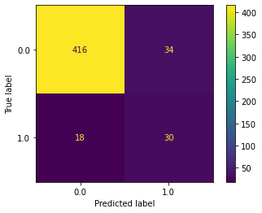

```python
plot_confusion_matrix(gaus_model,scaled_X_test,y_test);
```

```python
print(classification_report(y_test,gaus_pred))
```

```
              precision    recall  f1-score   support

         0.0       0.96      0.92      0.94       450
         1.0       0.47      0.62      0.54        48

    accuracy                           0.90       498
   macro avg       0.71      0.77      0.74       498
weighted avg       0.91      0.90      0.90       498
```

```python
confusion_matrix(y_test,gaus_pred)
```

```
array([[416,  34],
       [ 18,  30]])
```

```python
print(f'Accuracy on Training data: {gaus_model.score(scaled_X_train, y_train)}' )
print(f'Accuracy on Test data: {gaus_model.score(scaled_X_test, y_test)}' )
```

```
Accuracy on Training data: 0.8886657742079429
Accuracy on Test data: 0.8955823293172691
```

Accuracies on Training and test for Guassian Model

```python
# when we use regular sameple data (without smotenc),we get bad precision and recall score
```

```python
# we will balance the target class using smotenc and check the model performance
```

```python
# separate the target and features and perform train-test split
X = df.drop(['LoanOnCard'],axis=1)
y = df['LoanOnCard']
```

```python
smote_nc = SMOTENC(categorical_features=[3, 5, 7, 8,9,10], random_state=42)
X, y = smote_nc.fit_resample(X, y)
```

```python
X_train, X_test, y_train, y_test = train_test_split(X, y, test_size=0.30, random_state=42)
scaler = StandardScaler()
scaled_X_train = scaler.fit_transform(X_train)
scaled_X_test = scaler.transform(X_test)
```

```python
gaus_model = GaussianNB()
gaus_model.fit(scaled_X_train,y_train.ravel())
gaus_pred = gaus_model.predict(scaled_X_test)
print(classification_report(y_test,gaus_pred))
```

```
              precision    recall  f1-score   support

         0.0       0.89      0.89      0.89      1346
         1.0       0.89      0.89      0.89      1354

    accuracy                           0.89      2700
   macro avg       0.89      0.89      0.89      2700
weighted avg       0.89      0.89      0.89      2700
```

```python
# the predictions are better when we balance the target class, but lower than the Log regression model
```

1. Conclusion and improvisation:  
   • Write your conclusion on the results.  
   • Detailed suggestions or improvements or on quality, quantity, variety, velocity, veracity etc. on the data points collected by the bank to perform a better data analysis in future.

We performed our dataset on four models, 2 log regression and 2 Naive bayes; Of the four models, the model where we balance the target class using Smotenc performed well and has the best precision, recall and accuracy. We can conclude that log Regression is the best classifer for this dataset. With respect to data, effort can be made to collect more data on the imbalanced class so that our model will perform well with real data. As the units were masked, we were unable to understand the context of the data. Also, there were many cases where the loan on card was avaialble when customers did not have a credit card - this is an issue with the dataset.